# Atividade 2 - PCA

Análise Multivariada - 2026.1

Autor

Milena Paz Freitas

Este documento apresenta as resoluções dos exercícios propostos – em grande parte do livro de Johnson; Wichern (2002), *Applied multivariate statistical analysis* – que foram realizados com o objetivo de compreender o processo de análise de componentes principais e a álgebra linear por trás do mesmo.

# Exercícios

## Questão 1

**NotaEnunciado**

Os dados do arquivo `solo.txt` são observações de uma amostra aleatória constituída de 20 amostras de um determinado solo. Para cada amostra foram medidas as percentagens de areia, sedimentos, argila, quantidade de material orgânico e a acidez do solo (pH). Observe que as porcentagens de areia, sedimentos e argila somam 100%.

1. Calcule a matriz de covariância amostral S e a decomponha em seus autovalores. Mostre que a partir daí que esta matriz é não negativa definida.
2. Calcule os autovetores normalizados e calcule as componentes principais amostrais. Qual é a consequência de a) nas componentes que você construiu?
3. Escolha uma estratégia para tornar a matriz S positiva definida. Explique sua estratégia.
4. Faça agora uma análise de componentes principais usando a matriz positiva definida que você encontrou em c). Interprete as componentes e faça uma análise dizendo quantas componentes deveriam ser retidas para explicar aproximadamente a estrutura de variabilidade das variáveis originais. Calcule as correlações das componentes que você decidiu reter no sistema com todas as variáveis originais.
5. Para cada componente que você eliminou em d) teste a hipótese de que o autovalor teórico correspondente à componente é igual a zero.
6. Escolha a componente que achar mais conveniente para comparar as 20 amostras de solo entre si. Calcule o escore da componente para cada uma das vinte observações. Faça uma análise destes escores e tire alguma conclusão.
7. Faça agora uma análise de componentes principais usando a matriz de correlação amostral R calculada a partir da matriz positiva definida do item c). Compare os resultados com aqueles encontrados em d).
8. Repita o item f) considerando a análise que você fez em g).

```r
x <- as.matrix(read.table("solo.txt",header=T,dec=",",row.names = 1))
S <- cov(x)
S.eig <- eigen(S)
lambda <- S.eig$values
lambda #lambda 5 é zero, muito pequeno.
```

```
[1]  2.238414e+02  8.218110e+00  4.724624e-01  2.584501e-01 -4.123715e-15
```

Como os autovalores da matriz S são tais que $\lambda_1\geq...\geq\lambda_5\geq0$, temos que a matriz S é positiva semidefinida. Seus autovetores então são obtidos:

```r
E <- S.eig$vectors
#Componentes principais
Y <- x%*%E
```

Como a matriz S tem autovalores maiores ou iguais a zero, temos que a representação dos dados por meio de componentes principais é possível e coerente, já que os autovalores em questão são a variância explicada pelas componentes $Var(\boldsymbol Y_i)$ (e variância não pode ser negativa). A componente que corresponde ao autovalor nulo costuma ser insignificante. O que acontece é que, como as porcentagens de areia, sedimentos e argila somam 100%, uma variável é totalmente dependente das outras duas (colinearidade). Assim, uma estratégia para tornar a matriz S positiva definida seria simplesmente retirar uma das três variáveis, que ficaria como valor implícito. No R:

```r
S <- cov(x[,-3])
S.eig <- eigen(S)
lambda <- S.eig$values
lambda
```

```
[1] 215.2868879   2.9728812   0.4529535   0.2582774
```

```r
E <- S.eig$vectors
```

Isso, porém, ocasiona na perda de interpretabilidade das componentes. Como todos os autovalores são positivos e não-nulos, $S$ é positiva definida. Faremos, então, uma ACP usando essa matriz:

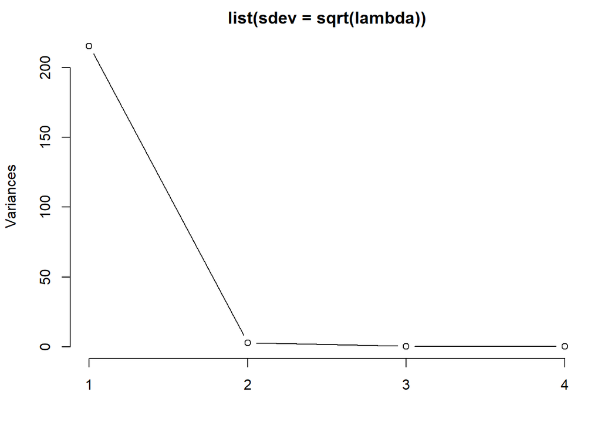

```r
par(mar=c(4.1,4.1,2,1))
#dados centrados
xc <- scale(x,scale=F)
#escores centrados
Y <- xc[,-3]%*%E
screeplot(list(sdev=sqrt(lambda)),type='l')
```

```r
perc <- lambda/sum(lambda)*100
tabela.val <- cbind(round(lambda,3),round(perc,2),round(cumsum(perc),1))
rownames(tabela.val) <- paste0("Comp",1:4)
colnames(tabela.val)  <- c("Autovalor","% Variância","% Acumulada")
tabela.val
```

```
      Autovalor % Variância % Acumulada
Comp1   215.287       98.32        98.3
Comp2     2.973        1.36        99.7
Comp3     0.453        0.21        99.9
Comp4     0.258        0.12       100.0
```

Buscando o “cotovelo” no screeplot, temos que duas componentes descrevem grande parte da variância, o que é confirmado pela tabela acima. Aqui temos a contribuição da cada variável a cada componente:

```r
V.meioinv <- diag(1/sqrt(diag(S)))
Lambda.meio <-diag(sqrt(lambda))
# matriz de correlacao entre Componente(i) e Variavel(k)
cor.YX<-V.meioinv%*%E%*%Lambda.meio
colnames(cor.YX) <- paste0("Comp",1:4)
rownames(cor.YX)  <- colnames(x)[-3]
#quantos % da variável está em cada componente?
round(cor.YX^2,5)*100
```

```
            Comp1  Comp2  Comp3  Comp4
areia      99.266  0.726  0.008  0.000
sedimentos 97.773  2.200  0.027  0.000
morganico   2.028 33.256 63.909  0.807
ph          0.055  0.034  3.659 96.253
```

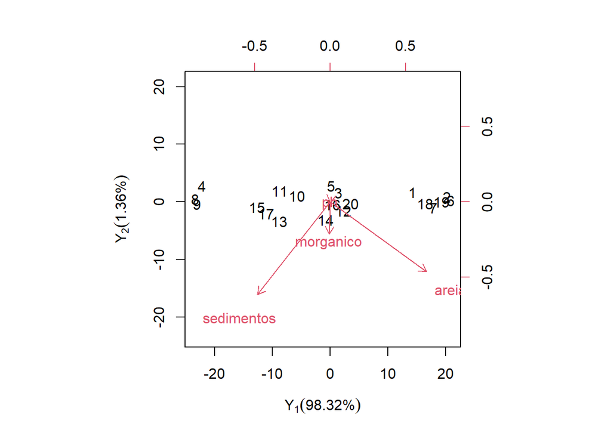

```r
## Graficamente
biplot(Y,E[,1:2],ylabs=colnames(x)[-3],
       xlab=expression(Y[1](98.32*'%')),ylab=expression(Y[2](1.36*'%')))
```

Daqui podemos observar que a variável ph é mal representada pelas 3 primeiras componentes. Interpretativamente, podemos dizer que as primeiras duas componentes representam bem as medidas concentração de areia e sedimentos; graficamente temos que os dois vetores se configuram quase ortogonais entre si.

Neste caso, é interessante reter a primeira componente, de forma que informe bem sobre as concentrações de materiais inorgânicos do solo. Podemos comparar com a saída da função do R `prcomp`:

```r
pc <- prcomp(x[,-3],scale.=F)
#autovalores
rbind(lambda,pc$sdev**2)|> round(9)
```

```
           [,1]     [,2]      [,3]      [,4]
lambda 215.2869 2.972881 0.4529535 0.2582774
       215.2869 2.972881 0.4529535 0.2582774
```

```r
#autovetores
E
```

```
             [,1]         [,2]       [,3]        [,4]
[1,]  0.798626731 -0.581392466  0.1541833  0.02014104
[2,] -0.601775756 -0.768097147  0.2171443  0.02722290
[3,] -0.007785819 -0.268290171 -0.9528179 -0.14176668
[4,] -0.000815571 -0.005473382 -0.1456500  0.98932071
```

```r
pc$rotation
```

```
                    PC1          PC2        PC3         PC4
areia      -0.798626731 -0.581392466 -0.1541833  0.02014104
sedimentos  0.601775756 -0.768097147 -0.2171443  0.02722290
morganico   0.007785819 -0.268290171  0.9528179 -0.14176668
ph          0.000815571 -0.005473382  0.1456500  0.98932071
```

```r
#gráfico
```

Vamos analisar os escores para a primeira componente:

```r
sort(Y[,1])
```

```
          8           9           4          15          17          13
-23.4240250 -23.1446319 -22.2811576 -12.7277299 -11.1300687  -8.8155908
         11          10          14           5          16           3
 -8.7814695  -5.7804100  -0.8110107   0.1837139   0.3668688   1.3981432
         12          20           1          18           7          19
  2.2785927   3.5687889  14.2840749  16.4763337  17.8875578  19.3346173
          2           6
 20.2421797  20.8752232
```

As observações mais positivas indicam maior concentração de areia. Aquelas mais próximas de zero nesta componente têm maior presença de argila e/ou material orgânico.

Agora, usando matriz de correlações no lugar da de covariância, realizamos novamente uma ACP:

```r
R <- V.meioinv%*%S%*%V.meioinv
R.eig <- eigen(R)
lambda <- R.eig$values
E <- R.eig$vectors
lambda
```

```
[1] 2.02289219 1.05046352 0.90577397 0.02087032
```

Espera-se que essa análise represente melhor as variáveis, pois reduz o efeito de diferença de escala entre os dados (especialmente apara pH, que segue escala logarítmica e foi muito mal representada na primeira análise).

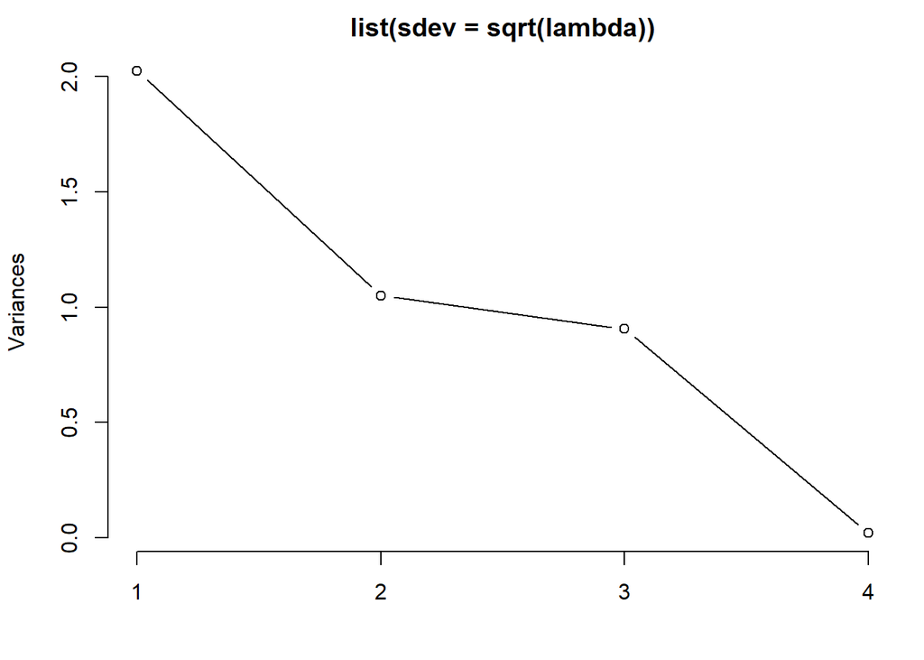

```r
par(mar=c(4.1,4.1,2,1))
screeplot(list(sdev=sqrt(lambda)),type='l')
```

```r
perc <- lambda/sum(lambda)*100
tabela.val <- cbind(round(lambda,3),round(perc,2),round(cumsum(perc),1))
rownames(tabela.val) <- paste0("Comp",1:4)
colnames(tabela.val)  <- c("Autovalor","% Variância","% Acumulada")
tabela.val
```

```
      Autovalor % Variância % Acumulada
Comp1     2.023       50.57        50.6
Comp2     1.050       26.26        76.8
Comp3     0.906       22.64        99.5
Comp4     0.021        0.52       100.0
```

```r
##escores
xp <- scale(x[,-3])
Y <- xp%*%E
##
Lambda.meio <-diag(sqrt(lambda))
# matriz de correlacao entre Componente(i) e Variavel(k)
#V.meioinv é identidade por R ser matriz de correlacoes
cor.YX<-E%*%Lambda.meio
colnames(cor.YX) <- paste0("Comp",1:4)
rownames(cor.YX)  <- colnames(xp)
#quantos % da variável está em cada componente?
round(cor.YX^2,5)*100
```

```
            Comp1  Comp2  Comp3 Comp4
areia      94.506  2.407  2.071 1.016
sedimentos 97.929  0.774  0.241 1.056
morganico   9.386 35.316 55.283 0.015
ph          0.468 66.550 32.982 0.000
```

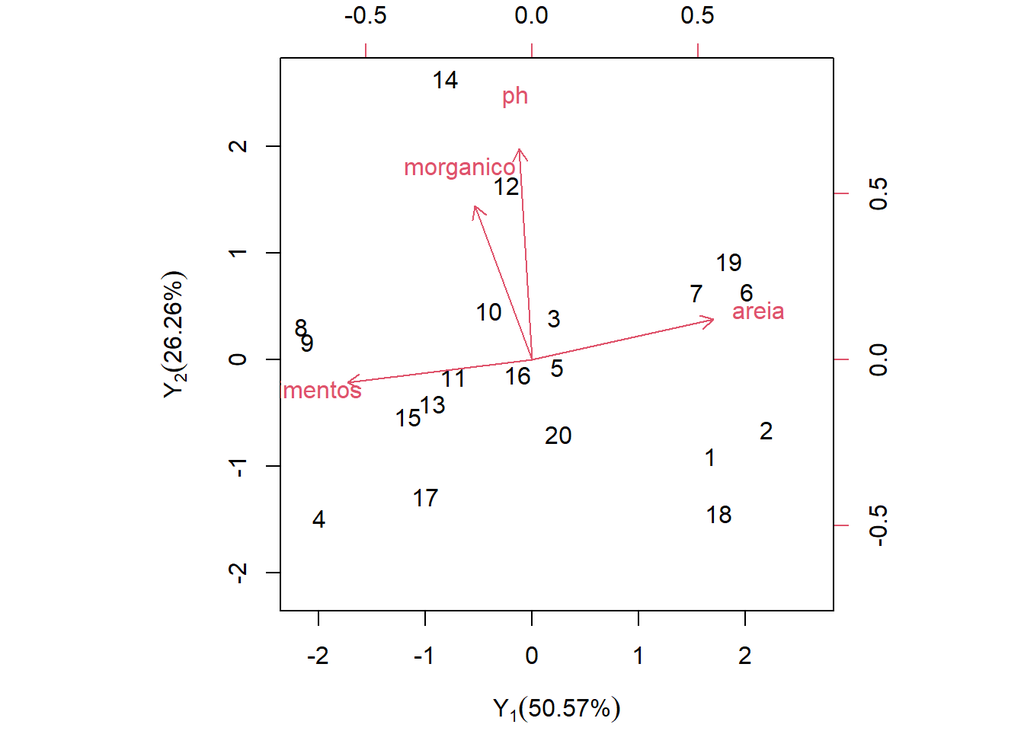

```r
## Graficamente
biplot(Y,E[,1:2],ylabs=colnames(xp),
       xlab=bquote(Y[1](.(round(perc[1],2))*'%')),
       ylab=bquote(Y[2](.(round(perc[2],2))*'%')))
```

Destes resultados podemos ver que as primeiras duas componentes representam bem melhor as variáveis que antes não estavam visíveis. Podemos associar, de certa forma, que o eixo da segunda componente corresponde à quantidade de material organico no sentido positivo e acidez no negativo (já que pH mais baixo é mais ácido). A componente 1 continua descrevendo principalmente as variáveis areia e sedimentos.

Observemos os escores:

```r
Y[,2]
```

```
          1           2           3           4           5           6
-0.90718222 -0.65610725  0.39606113 -1.48671622 -0.06801391  0.63673860
          7           8           9          10          11          12
 0.62894254  0.30802868  0.16798978  0.45755701 -0.16113324  1.63941385
         13          14          15          16          17          18
-0.41038446  2.63418732 -0.53496294 -0.13994932 -1.28579450 -1.44225349
         19          20
 0.92263527 -0.69905663
```

Solos como 14, 12 são solos mais básicos e com alto teor de material orgânico. Solos como 7, 19, 6 e 18 são de maiores concentrações de areia e menores de sedimentos.

Assim, temos que as componentes representam:

$Y_1$: Concentração de areia vs Outros materiais (não-organicos)

$Y_2$: Quantidade de material orgânico e basicidade.

## Questão 2

**NotaEnunciado**

Sejam $Y_i$, a i-ésima componente principal; $X_k$, a k-ésima variável e ($\lambda_i, \bm{e}_i$) o i-ésimo par de autovalores/autovetores da matriz de covariâncias $\Sigma$. Mostre que:

$$\text{Cor}(Y_i,X_k)=\frac{e_{ik}\sqrt\lambda_i}{\sqrt{\sigma_{kk}}},\quad i,k=1,2,...,p.$$

Basear-se na lista 1

Por definição:

$$\text{Cor}(Y_i,X_k)=\frac{\cov(Y_i,X_k)}{\sqrt{\sigma_{kk}Var(Y_i)}}$$

Tomando em conta que $Y_i=\bm e_i'X$ e $X_k=\bm a'X$, onde $\bm a$ é um vetor nulo, exceto pelo k-ésimo elemento que é igual a 1. Assim, usando propriedades de combinações lineares, a matriz de covariâncias:

$$\cov(\bm W)=\cov[(\bm e_i'X,\bm a'X)']=A\Sigma A',\quad A=\mat{\bm e_i'\\\bm a'}.$$
$$\Rightarrow A\Sigma A'=A\mat{\lambda_i\bm e_i& \bm\sigma_k},
\text{ onde } \bm\sigma_k\text{ é a k-ésima coluna de }\Sigma.$$

$$\Rightarrow A\Sigma A'=\mat{\lambda_i\bm{e_i}'\bm{e_i}&\lambda_ie_{ik}\\
\lambda_ie_{ik}&\sigma_{kk}}=\mat{\lambda_i&\lambda_ie_{ik}\\
\lambda_ie_{ik}&\sigma_{kk}}$$
Dessa matriz, temos que $\cov(\bm e_iX,\bm aX)=\lambda_ie_{ik}$. Além disso, sabemos que $Var(Y_i)=\lambda_i$:

$$\Rightarrow\text{Cor}(Y_i,X_k)=\frac{\lambda_ie_{ik}}{\sqrt{\sigma_{kk}\lambda_i}}=
\frac{\lambda_ie_{ik}\sqrt\lambda_i}{\sqrt{\sigma_{kk}}\lambda_i}=\frac{e_{ik}\sqrt\lambda_i}{\sqrt{\sigma_{kk}}}$$

## Questão 3

(JOHNSON; WICHERN, 2007: exercícios 8.1 e 8.2, pág. 470). Seja a matriz de covariâncias $\Sigma$:

$$\Sigma=\mat{5&2\\2&2}$$

1. Determine as componentes principais populacionais $Y_1$ e $Y_2$ para a matriz $\Sigma$.
2. Calcule a proporção de variância populacional total explicada pela primeira componente.
3. Converta a matriz de covariância $\Sigma$ para a matriz de correlações $\bm P$.
4. Determine as componentes principais de $\bm P$, $Y_1$ e $Y_2$, e calcule a proporção de variância populacional total explicada por $Y_1$.
5. Compare as componentes principais calculada em d) com aquelas obtidas em a). Elas são as mesmas? Elas deveriam ser as mesmas?
6. Calcule as correlações entre $Y_1$ e $Z_1$, $Y_1$ e $Z_2$, $Y_2$ e $Z_1$.

Os autovalores $\lambda_1$ e $\lambda_2$ são obtidos como solução da equação:

$$|\Sigma-\lambda I|=0 \Rightarrow \begin{vmatrix} 5-\lambda & 2\\2 &2-\lambda
\end{vmatrix} =0$$

E seus respectivos autovetores são solucão de:

$$(\Sigma - \lambda)\bm x=\bm0$$

No R, fazemos:

```r
Sigma <- matrix(c(5,2,2,2),ncol=2)
S.eig <- eigen(Sigma)
(E <- S.eig$vectors)
```

```
           [,1]       [,2]
[1,] -0.8944272  0.4472136
[2,] -0.4472136 -0.8944272
```

```r
(lambda <- S.eig$values)
```

```
[1] 6 1
```

As componentes são dadas por $Y=XE$, onde $E$ é a matriz cujas colunas são os autovetores de $\Sigma$ e X é a matriz de dados (nx2). A proporção de variância explicada pela primeira componente é:

```r
lambda[1]/sum(lambda)
```

```
[1] 0.8571429
```

```r
V.meioinv <- diag(1/sqrt(diag(Sigma)))
(P <- V.meioinv%*%Sigma%*%V.meioinv)
```

```
          [,1]      [,2]
[1,] 1.0000000 0.6324555
[2,] 0.6324555 1.0000000
```

Para fazer as componentes principais de $\bm P$, realizamos as mesmas operações, mas substituindo $\Sigma$ por $\bm P$:

```r
P.eig <- eigen(P)
(E <- P.eig$vectors)
```

```
           [,1]       [,2]
[1,] -0.7071068  0.7071068
[2,] -0.7071068 -0.7071068
```

```r
(lambda <- P.eig$values)
```

```
[1] 1.6324555 0.3675445
```

Aqui, temos que as componentes são dadas pela mesma operação, porém para as variáveis $Z$, que correspondem à padronização das variávels $X$, assim: $Y=ZE$. A proporção de variância explicada pela primeira componente é:

```r
lambda[1]/sum(lambda)
```

```
[1] 0.8162278
```

Ou seja, ela explica cerca de 82% da variância populacional total. Assim, temos que a padronização nivelou a escala de forma que, nas componentes, as variáveis contribuíssem igualmente. As correlações entre $Y$ e $Z$ são dadas por:

```r
Lambda.meio <- diag(sqrt(lambda))
cor.YZ<-E%*%Lambda.meio
colnames(cor.YZ) <- paste0("Y",1:2)
rownames(cor.YZ) <- paste0("Z",1:2)
cor.YZ
```

```
           Y1         Y2
Z1 -0.9034532  0.4286866
Z2 -0.9034532 -0.4286866
```

## Questão 4

**NotaEnunciado**

(JOHNSON; WICHERN, 2007: exercício 8.3, pág. 471). Seja a matriz de covariâncias:

$$\Sigma=\mat{2&0&0\\0&4&0\\0&0&4}$$

1. Determine as componentes principais populacionais $Y_1$, $Y_2$ e $Y_3$ para a matriz $\Sigma$.
2. Comente sobre os autovetores (e componentes principais) associados com os autovalores que não são distintos

Primeiro encontraremos os autovalores e autovetores de $\Sigma$:

```r
Sigma <- diag(c(2,4,4))
S.eig <- eigen(Sigma)
(E <- S.eig$vectors)
```

```
     [,1] [,2] [,3]
[1,]    0    0    1
[2,]    0    1    0
[3,]    1    0    0
```

```r
(lambda <- S.eig$values)
```

```
[1] 4 4 2
```

Assim, as componentes são dadas pelas combinações lineares dadas pela operação $Y=XE$. Desta forma, como os autovetores correspondentes a $\lambda=4$ não são únicos e, caso seja feita uma análise dessas componentes, é necessário evitar uma das duas.

## Questão 5

**NotaEnunciado**

(JOHNSON; WICHERN, 2007: exercício 8.10, pág. 473). O arquivo T8-4.dat contém as taxas de retorno semanais das ações de cinco empresas negociadas na New York Stock Exchange. No contexto dessa questão, define-se taxa de retorno semanal como: (preço de fechamento na semana atual – preço de fechamento na semana anterior)/preço de fechamento na semana anterior.

1. Construa a matriz de covariâncias amostrais S e encontre suas componentes principais.
2. Determine a proporção de variância amostral explicada pelas três primeiras componentes principais. Interprete essas componentes principais.
3. Construa os intervalos simultâneos de Bonferroni, com 90% de confiança para as variâncias $\lambda_1$, $\lambda_2$ e $\lambda_3$ das três primeiras componentes populacionais Y1, Y2 e Y3.
4. Considerando os resultados obtidos em a), b) e c), você considera que os dados das taxa de retorno desses ativos podem ser resumidas em menos que cinco dimensões? Comente

```r
x <- read.table("T8-4.DAT",
                col.names = c("JP Morgan","Citibank","Wells Fargo",
                              "Royal Dutch Shell","Exxon Mobil")) |>
  as.matrix()
```

## Referências

JOHNSON, R. A.; WICHERN, D. W. **Applied multivariate statistical analysis**. [s.l.] Prentice hall Upper Saddle River, NJ, 2002.